# Statistical Learning Project

## Q1

```python
## 1. Importing the libraries

import pandas as pd
import numpy as np
import matplotlib.pyplot as plt
import seaborn as sns
import scipy.stats as st
%matplotlib inline
sns.set()
```

## Q2

```python
## 2. Reading the data file into dataframe
insurance=pd.read_csv('insurance.csv')
```

```python
# display top 5 rows
insurance.head()
```

|  | age | sex | bmi | children | smoker | region | charges |
| --- | --- | --- | --- | --- | --- | --- | --- |
| 0 | 19 | female | 27.900 | 0 | yes | southwest | 16884.92400 |
| 1 | 18 | male | 33.770 | 1 | no | southeast | 1725.55230 |
| 2 | 28 | male | 33.000 | 3 | no | southeast | 4449.46200 |
| 3 | 33 | male | 22.705 | 0 | no | northwest | 21984.47061 |
| 4 | 32 | male | 28.880 | 0 | no | northwest | 3866.85520 |

## Q3

```python
## 3a. dataframe shape (Rows, columns)
print("dataframe has %i rows and %i columns" %insurance.shape)
```

```
dataframe has 1338 rows and 7 columns
```

```python
## dataframe information
insurance.info()
```

```
<class 'pandas.core.frame.DataFrame'>
RangeIndex: 1338 entries, 0 to 1337
Data columns (total 7 columns):
 #   Column    Non-Null Count  Dtype
---  ------    --------------  -----
 0   age       1338 non-null   int64
 1   sex       1338 non-null   object
 2   bmi       1338 non-null   float64
 3   children  1338 non-null   int64
 4   smoker    1338 non-null   object
 5   region    1338 non-null   object
 6   charges   1338 non-null   float64
dtypes: float64(2), int64(2), object(3)
memory usage: 73.3+ KB
```

```python
## 3b. datatype of each attribute
print("datatype for each attribute are:\n",insurance.dtypes)
print("\n number of attributes of each type are:\n",insurance.dtypes.value_counts())
```

```
datatype for each attribute are:
 age           int64
sex          object
bmi         float64
children      int64
smoker       object
region       object
charges     float64
dtype: object

 number of attributes of each type are:
 object     3
int64      2
float64    2
dtype: int64
```

```python
## 3c. checking the missing/null values
print("missing value count for each attribute:\n", insurance.isnull().sum())
print("total missing values=",insurance.isnull().sum().sum())
```

```
missing value count for each attribute:
 age         0
sex         0
bmi         0
children    0
smoker      0
region      0
charges     0
dtype: int64
total missing values= 0
```

```python
## 3d. five point summary for numerical columns
insurance.describe()
```

|  | age | bmi | children | charges |
| --- | --- | --- | --- | --- |
| count | 1338.000000 | 1338.000000 | 1338.000000 | 1338.000000 |
| mean | 39.207025 | 30.663397 | 1.094918 | 13270.422265 |
| std | 14.049960 | 6.098187 | 1.205493 | 12110.011237 |
| min | 18.000000 | 15.960000 | 0.000000 | 1121.873900 |
| 25% | 27.000000 | 26.296250 | 0.000000 | 4740.287150 |
| 50% | 39.000000 | 30.400000 | 1.000000 | 9382.033000 |
| 75% | 51.000000 | 34.693750 | 2.000000 | 16639.912515 |
| max | 64.000000 | 53.130000 | 5.000000 | 63770.428010 |

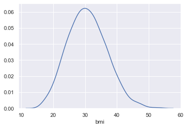

```python
## 3e. Distribution of i) bmi
sns.distplot(insurance.bmi, hist=False);
```

###### Bmi shows normal distribution with a bell shaped curve

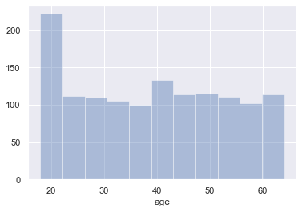

```python
## 3e. Distribution of ii) age
sns.distplot(insurance.age, kde=False);
```

###### Age seems to be uniformly distributed

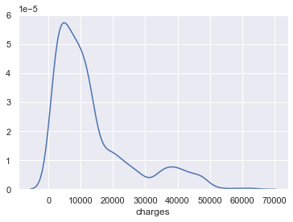

```python
## 3e. Distribution of iii) charges
sns.distplot(insurance.charges, hist=False);
```

###### Charges show a right skewed normal distribution

```python
## 3f. Measure of skewness of bmi, age and charges
print("skewness in bmi = %.3f, age = %.3f and charges = %.3f for given dataset" %(insurance.age.skew(),insurance.bmi.skew(),insurance.charges.skew()))
```

[output not shown]

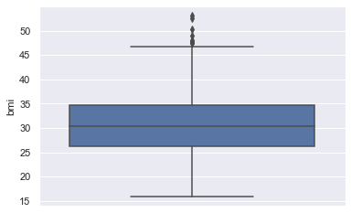

```python
## 3g. Outliers in i)bmi
sns.boxplot(data=insurance, y='bmi');
```

###### Normally distributed bmi has outliers between 46 and 55

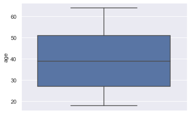

```python
## 3g. Outliers in ii)age
sns.boxplot(data=insurance, y='age');
```

###### uniformly distributed age doesn't have any outliers

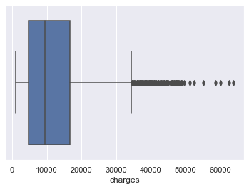

```python
## 3g. Outliers in iii)charges
sns.boxplot(data=insurance, x='charges');
```

###### Right skewed Normally distributed charges has multiple outliers between 33k and 65k

```python
# TO check categorical columns
insurance.nunique()
```

```
age           47
sex            2
bmi          548
children       6
smoker         2
region         4
charges     1337
dtype: int64
```

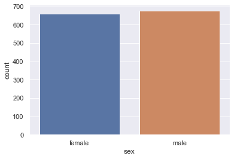

```python
## 3h. Distribution of categorical columns i)sex
sns.countplot(data=insurance, x='sex');
```

###### count of males and females is approximately equally distributed

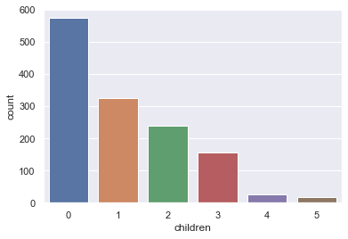

```python
## 3h. Distribution of categorical columns ii)children
sns.countplot(data=insurance, x='children');
```

###### distribution of chidren count decreases uniformly with number of children

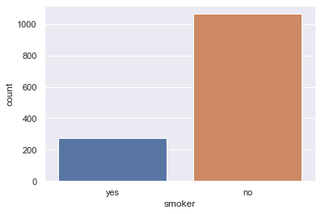

```python
## 3h. Distribution of categorical columns iii)smoker
sns.countplot(data=insurance, x='smoker');
```

###### The dataset has smokers to non smokers in the approx ratio of 1:4

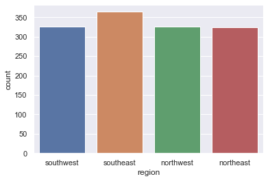

```python
## 3h. Distribution of categorical columns iv)region
sns.countplot(data=insurance, x='region');
```

###### The dataset is uniformly distributed in terms of count from each region

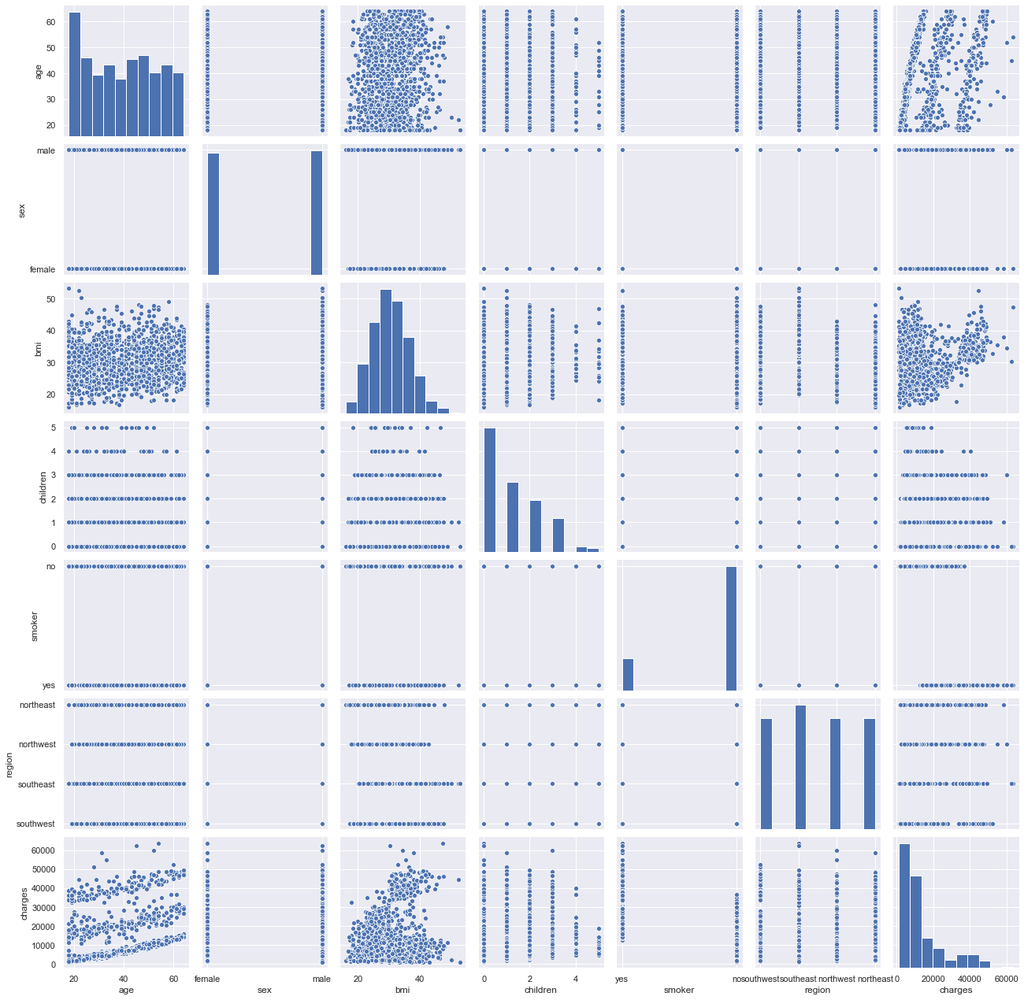

```python
## 3i. pair plot with all the columns included
sns.pairplot(insurance, vars=insurance.columns);
```

## Q4

#### 4a) Based on the question, we need to perform 2 sample t test

##### here H0: u1=u2 (mean of charges for people who smoke and who don't are equal)

###### => Charges of people who smoke doesn't differ from charges of people who don't.

##### Ha: u1!=u2 (mean of charges differ for smokers and non smokers)

###### => Charges of people who smoke differ significantly from charges of people who don't.

### Let's Assume alpha (level of significance=0.05)

```python
## slicing the dataframe for required columns
insurance[['smoker','charges']].head()
```

|  | smoker | charges |
| --- | --- | --- |
| 0 | yes | 16884.92400 |
| 1 | no | 1725.55230 |
| 2 | no | 4449.46200 |
| 3 | no | 21984.47061 |
| 4 | no | 3866.85520 |

```python
## Splitting the data into 2 subsets- smokers and non smokers
smokers=insurance[insurance.smoker=='yes']['charges']
nsmokers=insurance[insurance.smoker=='no']['charges']
print(smokers.var())
print(smokers.size)
print(nsmokers.var())
print(nsmokers.size)
```

```
133207311.20634921
274
35925420.49611172
1064
```

```python
## randomly sampling n samples from larger dataset where n = size of smaller dataset
## calculating its variance
print(nsmokers.sample(274).var())
```

```
34703110.19485345
```

```python
## since the variance differ for two samples,
## checking ratio of variance to decide if variance is to be assumed equal or not
print(np.var(nsmokers.sample(274))/np.var(smokers))
print(np.var(nsmokers)/np.var(smokers))
```

```
0.23925002399649486
0.27042905486450575
```

```python
## performing t test independent using ttest_ind of stats module
tstat,pval=st.ttest_ind(smokers,nsmokers.sample(274))
print("t-statistics= %.4f and p-value= %.4f for subsets with equal size"
      %(tstat,pval))
tstat2,pval2=st.ttest_ind(smokers,nsmokers)
print("t-statistics=%.4f and p-value=%.4f for subsets with different sizes"
      %(tstat2,pval2))
```

```
t-statistics= 29.1728 and p-value= 0.0000 for subsets with equal size
t-statistics=46.6649 and p-value=0.0000 for subsets with different sizes
```

###### Since pval is less than alpha, we reject the null hypothesis

### => charges of people who smoke differ significantly from the people who don't

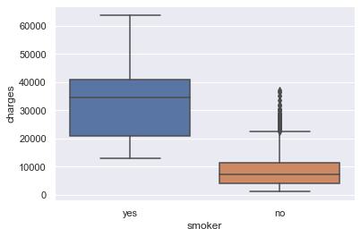

```python
## The conclusion can be seen clearly with boxplot distribution.
sns.boxplot(data=insurance, x='smoker', y='charges');
```

#### 4b) Based on the question, we need to perform 2 sample t test

##### here H0: u1=u2 (mean of bmi for males and females are equal)

###### => bmi of males do not differ significantly from that of females

##### Ha: u1!=u2 (mean of bmi for males and females are not equal)

###### => bmi of males differ significantly from that of females

### Let's Assume alpha (level of significance=0.05)

```python
## checking the dataframe for required columns
insurance[['sex','bmi']].head()
```

|  | sex | bmi |
| --- | --- | --- |
| 0 | female | 27.900 |
| 1 | male | 33.770 |
| 2 | male | 33.000 |
| 3 | male | 22.705 |
| 4 | male | 28.880 |

```python
## Splitting the data into 2 subsets- males and females
male_bmi=insurance[insurance.sex=='male']['bmi']
female_bmi=insurance[insurance.sex=='female']['bmi']
print(male_bmi.var())
print(male_bmi.size)
print(female_bmi.var())
print(female_bmi.size)
```

```
37.70493727081969
676
36.554395153365576
662
```

###### Since variance are comparable, performing 2 sample t-test

```python
## performing t test independent using ttest_ind of stats module
tstat,pval=st.ttest_ind(male_bmi,female_bmi)
print("t-statistics= %.4f and p-value= %.4f for subsets with equal size"
      %(tstat,pval))
```

[output not shown]

#### Since pval(0.09) > alpha(0.05), we fail to reject the null hypothesis

### => BMI of males do not differ significantly from that of females

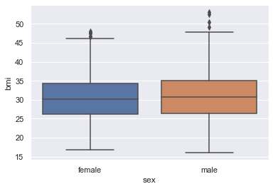

```python
## The conclusion can be seen clearly with boxplot distribution.
sns.boxplot(data=insurance, x='sex', y='bmi');
```

#### 4c) Based on the question, we need to perform Proportions z-test

##### here H0: p1=p2 (proportion of smokers in males and females is equal)

###### => proportion of male smokers do not differ significantly from that of female smokers

##### Ha: p1!=p2 (proportion of smokers for males and females is not equal)

###### => proportion of smokers in males differ significantly from that in females

### Let's Assume alpha (level of significance=0.05)

```python
# for proportions z-test we need to import proportions_ztest from statsmodels
import statsmodels.stats.proportion as prop
```

```python
## checking the dataframe for required columns
insurance[['sex','smoker']].head()
```

|  | sex | smoker |
| --- | --- | --- |
| 0 | female | yes |
| 1 | male | no |
| 2 | male | no |
| 3 | male | no |
| 4 | male | no |

```python
## Calculating the counts and proportions for the given categories
m_smokers=insurance[insurance.sex=='male'].smoker.value_counts()['yes']
f_smokers=insurance[insurance.sex=='female'].smoker.value_counts()['yes']
n_male=insurance.sex.value_counts()['male']
n_female=insurance.sex.value_counts()['female']

print("There are %i smokers in %i males and %i smokers in %i females"
      %(m_smokers,n_male,f_smokers,n_female))
print("Proportion of male smokers=%.3f and Proportion of female smokers=%.3f "
     %(m_smokers/n_male,f_smokers/n_female))
```

```
There are 159 smokers in 676 males and 115 smokers in 662 females
Proportion of male smokers=0.235 and Proportion of female smokers=0.174
```

```python
# performing proportion ztest using proportions_ztest of statsmodels.proportions
zstat,pval=prop.proportions_ztest([m_smokers,f_smokers],[n_male,n_female])
print("z-statistics= %.4f and p-value= %.4f for the two proportions"
      %(zstat,pval))
```

```
z-statistics= 2.7867 and p-value= 0.0053 for the two proportions
```

###### Since pval(0.005) is less than alpha(0.05), we reject the null hypothesis

### =>Proportion of smokers differ significantly in different genders

#### 4c) Based on the question, we need to perform ANOVA test

##### here H0: u1=u2=u3 (mean of bmi across women with no children, one child and two children is same)

###### => distribution of bmi across women with no children, one child and two children is the same

##### Ha: p=u1!=u2!=u3 (mean of bmi across women with no children, one child and two children is not the same)

###### => distribution of bmi across women with no children, one child and two children differ significantly

### Let's Assume alpha (level of significance=0.05)

```python
## checking the dataframe for required columns
insurance[insurance.sex=='female'][['children','bmi']].head()
```

|  | children | bmi |
| --- | --- | --- |
| 0 | 0 | 27.90 |
| 5 | 0 | 25.74 |
| 6 | 1 | 33.44 |
| 7 | 3 | 27.74 |
| 9 | 0 | 25.84 |

```python
## Calculating the mean bmi of women with 0,1,2 children
insurance[insurance.sex=='female'].groupby('children').mean()['bmi'][[0,1,2]]
```

```
children
0    30.361522
1    30.052658
2    30.649790
Name: bmi, dtype: float64
```

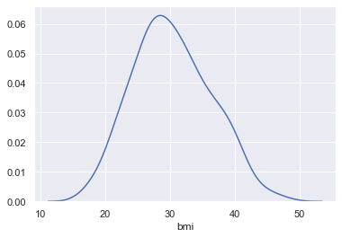

```python
## Checking the distribution of bmi in women with no children
sns.distplot(insurance[(insurance.sex=='female') & (insurance.children==0)]['bmi'], hist=False);
```

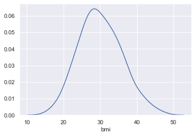

```python
## Checking the distribution of bmi in women with 1 child
sns.distplot(insurance[(insurance.sex=='female') & (insurance.children==1)]['bmi'], hist=False);
```

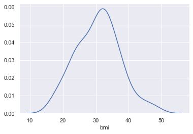

```python
## Checking the distribution of bmi in women with 2 children
sns.distplot(insurance[(insurance.sex=='female') & (insurance.children==2)]['bmi'],hist=False);
```

###### The distribution is a bell shaped curve for all three scenarios

###### So performing anova test using statsmodels method on subset of dataframe with sex= female and number of children 0 or 1 or 2

```python
import statsmodels.api         as     sm
from   statsmodels.formula.api import ols

mod = ols('bmi ~ children', data = insurance[(insurance.sex=='female') & (insurance.children.isin([0,1,2]))]).fit()
aov_table = sm.stats.anova_lm(mod, typ=1)
print(aov_table)
```

```
             df        sum_sq    mean_sq         F   PR(>F)
children    1.0      2.512982   2.512982  0.068411  0.79376
Residual  564.0  20717.738725  36.733579       NaN      NaN
```

#### Here pval=0.794 which is greater than alpha (0.05)

###### hence we fail to reject the null hypothesis

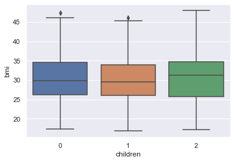

```python
## The conclusion can be visualised with the boxplot distribution.
sns.boxplot(x='children', y='bmi', data=insurance[(insurance.sex=='female') & (insurance.children.isin([0,1,2])) ]);
```